# Clustering (Unsupervised Learning)

### K - Means Algorithm

k = number of clusters The algorithm creates k centroids and calculates the means of the distances from the centroid to the distances of the data points and continues to do so until the calculated means do not change or the centroids do not switch between groups of data.

```python
from sklearn.cluster import KMeans
from sklearn.metrics import silhouette_score
import matplotlib.pyplot as plt
import pandas as pd
import numpy as np

%matplotlib inline
```

```python
data = pd.read_excel('cars.xls')
data.head()
```

|  | Price | Mileage | Make | Model | Trim | Type | Cylinder | Liter | Doors | Cruise | Sound | Leather |
| --- | --- | --- | --- | --- | --- | --- | --- | --- | --- | --- | --- | --- |
| 0 | 17314.103129 | 8221 | Buick | Century | Sedan 4D | Sedan | 6 | 3.1 | 4 | 1 | 1 | 1 |
| 1 | 17542.036083 | 9135 | Buick | Century | Sedan 4D | Sedan | 6 | 3.1 | 4 | 1 | 1 | 0 |
| 2 | 16218.847862 | 13196 | Buick | Century | Sedan 4D | Sedan | 6 | 3.1 | 4 | 1 | 1 | 0 |
| 3 | 16336.913140 | 16342 | Buick | Century | Sedan 4D | Sedan | 6 | 3.1 | 4 | 1 | 0 | 0 |
| 4 | 16339.170324 | 19832 | Buick | Century | Sedan 4D | Sedan | 6 | 3.1 | 4 | 1 | 0 | 1 |

```python
x = data[['Price','Mileage','Cylinder']]
x.head()
```

|  | Price | Mileage | Cylinder |
| --- | --- | --- | --- |
| 0 | 17314.103129 | 8221 | 6 |
| 1 | 17542.036083 | 9135 | 6 |
| 2 | 16218.847862 | 13196 | 6 |
| 3 | 16336.913140 | 16342 | 6 |
| 4 | 16339.170324 | 19832 | 6 |

```python
model = KMeans(n_clusters = 5)
model
```

```
KMeans(algorithm='auto', copy_x=True, init='k-means++', max_iter=300,
    n_clusters=5, n_init=10, n_jobs=1, precompute_distances='auto',
    random_state=None, tol=0.0001, verbose=0)
```

```python
model = model.fit(x)
```

```python
pred = model.predict(x)
pred
```

```
array([0, 0, 0, 2, 2, 2, 2, 2, 2, 1, 0, 2, 2, 2, 2, 2, 2, 1, 1, 1, 0, 0, 0,
       2, 2, 2, 2, 2, 1, 1, 2, 2, 2, 2, 2, 1, 1, 1, 1, 1, 0, 0, 2, 2, 2, 2,
       1, 1, 1, 1, 2, 2, 2, 2, 2, 2, 1, 1, 1, 1, 0, 0, 2, 2, 2, 2, 2, 2, 1,
       1, 0, 0, 0, 0, 4, 4, 4, 1, 1, 1, 3, 3, 3, 3, 3, 3, 3, 4, 4, 4, 3, 4,
       4, 4, 4, 4, 4, 4, 4, 4, 3, 3, 3, 3, 4, 4, 4, 4, 4, 4, 3, 3, 3, 3, 4,
       4, 4, 4, 4, 4, 3, 3, 3, 3, 4, 4, 4, 4, 4, 4, 3, 3, 3, 3, 4, 4, 4, 4,
       4, 4, 3, 3, 3, 3, 3, 3, 4, 4, 4, 4, 3, 3, 3, 3, 3, 3, 3, 3, 3, 4, 0,
       0, 2, 2, 2, 2, 2, 2, 1, 1, 0, 0, 0, 0, 2, 2, 2, 2, 1, 1, 2, 2, 2, 2,
       2, 2, 1, 1, 1, 1, 0, 0, 2, 2, 2, 2, 1, 1, 1, 1, 0, 0, 0, 2, 2, 2, 2,
       2, 2, 1, 0, 2, 2, 2, 2, 1, 1, 1, 1, 1, 0, 2, 2, 2, 2, 2, 2, 1, 1, 1,
       0, 0, 2, 2, 2, 2, 2, 2, 1, 1, 0, 0, 0, 2, 2, 1, 1, 1, 1, 1, 0, 0, 0,
       2, 2, 2, 2, 2, 2, 1, 0, 0, 2, 2, 2, 2, 2, 2, 2, 1, 0, 2, 2, 2, 2, 2,
       1, 1, 1, 1, 0, 0, 2, 2, 2, 2, 2, 2, 1, 1, 2, 2, 2, 2, 2, 2, 2, 1, 1,
       1, 0, 0, 2, 2, 1, 1, 1, 1, 1, 1, 0, 0, 2, 2, 2, 2, 2, 2, 1, 1, 0, 0,
       2, 2, 2, 2, 2, 2, 2, 2, 0, 0, 0, 0, 2, 2, 2, 2, 1, 1, 3, 3, 3, 3, 3,
```

[output cut: 20 more lines]

```python
x['new cluster'] = pred
x.head()
```

|  | Price | Mileage | Cylinder | new cluster |
| --- | --- | --- | --- | --- |
| 0 | 17314.103129 | 8221 | 6 | 0 |
| 1 | 17542.036083 | 9135 | 6 | 0 |
| 2 | 16218.847862 | 13196 | 6 | 0 |
| 3 | 16336.913140 | 16342 | 6 | 2 |
| 4 | 16339.170324 | 19832 | 6 | 2 |

The silhouette value is a measure of how similar an object is to its own cluster (cohesion) compared to other clusters (separation). The silhouette ranges from -1 to 1, where a high value indicates that the object is well matched to its own cluster and poorly matched to neighboring clusters. If most objects have a high value, then the clustering configuration is appropriate. If many points have a low or negative value, the the clustering configuration may have too many or too few clusters. The Silhouette Coefficient for a sample is (b-a)/max(a,b)

```python
silhouette_score(x,pred)
```

```
0.3544457891439895
```

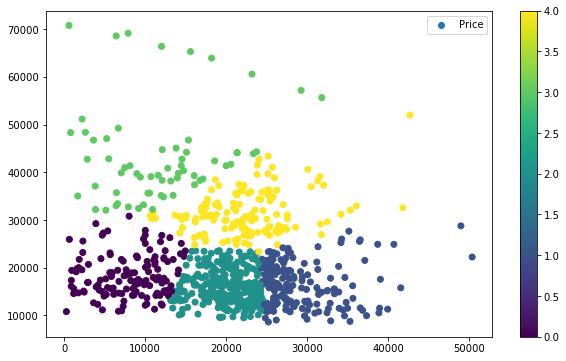

```python
# Visualize the data clusters
plt.figure(figsize=(10,6))
plt.scatter(x.Mileage,x.Price,c=pred)
plt.legend()
plt.colorbar()
plt.show()
```

```python
model.cluster_centers_
```

```
array([[  1.84179663e+04,   8.03421642e+03,   5.07462687e+00],
       [  1.63211829e+04,   2.90157322e+04,   5.09289617e+00],
       [  1.58318151e+04,   1.99361786e+04,   4.97142857e+00],
       [  4.34180038e+04,   1.18960317e+04,   7.07936508e+00],
       [  3.15059802e+04,   2.24085486e+04,   5.45833333e+00]])
```

```python
model.labels_
```

```
array([0, 0, 0, 2, 2, 2, 2, 2, 2, 1, 0, 2, 2, 2, 2, 2, 2, 1, 1, 1, 0, 0, 0,
       2, 2, 2, 2, 2, 1, 1, 2, 2, 2, 2, 2, 1, 1, 1, 1, 1, 0, 0, 2, 2, 2, 2,
       1, 1, 1, 1, 2, 2, 2, 2, 2, 2, 1, 1, 1, 1, 0, 0, 2, 2, 2, 2, 2, 2, 1,
       1, 0, 0, 0, 0, 4, 4, 4, 1, 1, 1, 3, 3, 3, 3, 3, 3, 3, 4, 4, 4, 3, 4,
       4, 4, 4, 4, 4, 4, 4, 4, 3, 3, 3, 3, 4, 4, 4, 4, 4, 4, 3, 3, 3, 3, 4,
       4, 4, 4, 4, 4, 3, 3, 3, 3, 4, 4, 4, 4, 4, 4, 3, 3, 3, 3, 4, 4, 4, 4,
       4, 4, 3, 3, 3, 3, 3, 3, 4, 4, 4, 4, 3, 3, 3, 3, 3, 3, 3, 3, 3, 4, 0,
       0, 2, 2, 2, 2, 2, 2, 1, 1, 0, 0, 0, 0, 2, 2, 2, 2, 1, 1, 2, 2, 2, 2,
       2, 2, 1, 1, 1, 1, 0, 0, 2, 2, 2, 2, 1, 1, 1, 1, 0, 0, 0, 2, 2, 2, 2,
       2, 2, 1, 0, 2, 2, 2, 2, 1, 1, 1, 1, 1, 0, 2, 2, 2, 2, 2, 2, 1, 1, 1,
       0, 0, 2, 2, 2, 2, 2, 2, 1, 1, 0, 0, 0, 2, 2, 1, 1, 1, 1, 1, 0, 0, 0,
       2, 2, 2, 2, 2, 2, 1, 0, 0, 2, 2, 2, 2, 2, 2, 2, 1, 0, 2, 2, 2, 2, 2,
       1, 1, 1, 1, 0, 0, 2, 2, 2, 2, 2, 2, 1, 1, 2, 2, 2, 2, 2, 2, 2, 1, 1,
       1, 0, 0, 2, 2, 1, 1, 1, 1, 1, 1, 0, 0, 2, 2, 2, 2, 2, 2, 1, 1, 0, 0,
       2, 2, 2, 2, 2, 2, 2, 2, 0, 0, 0, 0, 2, 2, 2, 2, 1, 1, 3, 3, 3, 3, 3,
```

[output cut: 20 more lines]

```python
# Creating a loop to loop through a range of clusters and see which number of clusters gives us the best silhouette score,
# thus giving us the best model

silScores = []

def clust(clusters):
    bestClustNum = 0
    silScore = 0
    for num_of_cluster in np.arange(1,clusters):
        num_of_cluster += 1
        model = KMeans(n_clusters=num_of_cluster)
        model = model.fit(x)
        pred = model.predict(x)
        score = silhouette_score(x,pred)
        print 'Number of Clusters {}, silhouette score {}'.format(num_of_cluster,score)

        if score > silScore:
            silScore = score
            bestClustNum = num_of_cluster

        silScores.append(score)

    print 'The best number of Clusters is {} with a silhouette score of {}'.format(bestClustNum,silScore)

clust(20)
silScores
```

```
Number of Clusters 2, silhouette score 0.451145420319
Number of Clusters 3, silhouette score 0.413210865832
Number of Clusters 4, silhouette score 0.413286093659
Number of Clusters 5, silhouette score 0.355218347953
Number of Clusters 6, silhouette score 0.363436162479
Number of Clusters 7, silhouette score 0.357516123854
Number of Clusters 8, silhouette score 0.368463252368
Number of Clusters 9, silhouette score 0.349115959965
Number of Clusters 10, silhouette score 0.355018959202
Number of Clusters 11, silhouette score 0.358482151876
Number of Clusters 12, silhouette score 0.36523064763
Number of Clusters 13, silhouette score 0.353496211736
Number of Clusters 14, silhouette score 0.35858477856
Number of Clusters 15, silhouette score 0.347898689048
Number of Clusters 16, silhouette score 0.356955236674
Number of Clusters 17, silhouette score 0.357704782134
Number of Clusters 18, silhouette score 0.356481500488
Number of Clusters 19, silhouette score 0.352767719712
Number of Clusters 20, silhouette score 0.348674348196
The best number of Clusters is 2 with a silhouette score of 0.451145420319
```

```
[0.4511454203189893,
 0.41321086583208377,
 0.4132860936585307,
 0.35521834795309348,
 0.36343616247896399,
 0.3575161238544769,
 0.36846325236832911,
 0.34911595996509309,
 0.35501895920207749,
 0.35848215187637755,
 0.36523064763013019,
 0.35349621173628853,
 0.35858477855967297,
 0.34789868904830923,
 0.35695523667367018,
 0.35770478213399731,
 0.35648150048841337,
 0.35276771971226706,
 0.3486743481958568]
```

# Classification Algorithm

k nearest neighbors calculates distance from points to groups of the points closest to it and determines which quality it is most like. It is highly recommended to scale or normalize your data when using K-nearest neighbors so some values do not have significantly higher weight than others.

```python
data = pd.read_csv('heightweight.csv')
data_weight = data[['weightLb','ageYear']]
data_weight.head()
```

|  | weightLb | ageYear |
| --- | --- | --- |
| 0 | 85.0 | 11.91667 |
| 1 | 105.0 | 12.91667 |
| 2 | 108.0 | 12.75000 |
| 3 | 92.0 | 13.41667 |
| 4 | 112.5 | 15.91667 |

```python
from sklearn.preprocessing import scale
data_scaled = scale(data_weight)
data_scaled
```

```
array([[-0.840635  , -1.16552514],
       [ 0.19031193, -0.51288498],
       [ 0.34495397, -0.62166052],
       [-0.47980357, -0.1865649 ],
       [ 0.57691704,  1.4450355 ],
       [ 0.55114336,  0.35729973],
       [ 0.13876459,  1.11871542],
       [-1.66539255, -1.21991618],
       [-0.35093521, -0.24095593],
       [-1.69116622, -1.32868518],
       [ 0.13876459, -1.38307622],
       [ 0.11299091,  0.73800431],
       [ 1.14393785, -0.40411597],
       [-0.42825623, -0.83920506],
       [-2.61901847, -1.16552514],
       [-0.63444561, -1.05675613],
       [ 0.29340663,  1.4450355 ],
       [-1.17569276, -0.78482056],
       [ 0.7057854 , -0.9479806 ],
       [ 0.65423806,  0.84677985],
       [-0.840635  , -1.27430068],
       [-1.04682439, -1.32868518],
       [-0.91795602, -0.02340486],
       [ 0.55114336,  0.6292353 ],
       [-0.01587745,  1.11871542],
       [ 0.11299091,  0.08536415],
       [-0.40248255,  0.57484427],
       [ 0.55114336,  0.84677985],
       [ 1.99446907,  2.47838025],
       [-0.91795602, -1.0023651 ],
       [-0.58289827,  0.30291522],
       [-0.89218235, -0.1321804 ],
       [ 0.47382234, -0.83920506],
       [-0.27361419, -1.38307622],
       [-0.32516153,  1.17309993],
       [ 1.01506948,  1.77135559],
       [-0.09319847,  0.24852419],
       [ 2.12333744,  0.68361981],
       [ 0.86042744,  1.11871542],
       [ 0.16453826,  0.95555538],
```

[output cut: 182 more lines]

```
       [-1.35610847, -0.1865649 ],
       [ 1.37590091, -0.62166052],
       [-0.17051949,  1.71696455],
       [-0.89218235, -0.02340486],
       [-0.11897215, -0.29534044],
       [ 0.55114336,  0.73800431],
       [-1.12414541, -0.62166052],
       [-1.07259806, -0.51288498],
       [ 0.06144357,  0.73800431],
       [-1.30456112, -1.21991618],
       [ 0.55114336, -0.02340486],
       [ 0.65423806,  1.33625997],
       [ 1.99446907, -0.02340486],
       [ 0.3191803 ,  0.13975518],
       [-0.73754031, -0.73043605]])
```

```python
from sklearn.neighbors import KNeighborsClassifier
neigh = KNeighborsClassifier(n_neighbors=25)
model = neigh.fit(data_weight,data.sex)
```

```python
print "Predicted Gender = ",model.predict([[110,19.0]])
```

```
Predicted Gender =  ['f']
```

# Naive Bayes

Naive because we assume that all conditions are independent of each other. This assumption makes the math easier and the algorithm faster. However, this assumption is generally not true. Top uses for this algorithm are spam filters and document classification.

```python
import os
import io
import numpy as np
from pandas import DataFrame
from sklearn.feature_extraction.text import CountVectorizer
from sklearn.naive_bayes import MultinomialNB
```

```python
!cd
```

```
C:\Users\nwerner\DevMasters\Class Notes\Day #5 - Classifier Algorithms
```

```python
filenames = []
for files in os.walk('C:\\Users\\nwerner\\DevMasters\\Class Notes\\Day #5 - Classifier Algorithms'):
    filenames.append(files)
```

```python
filenames
```

```
[('C:\\Users\\nwerner\\DevMasters\\Class Notes\\Day #5 - Classifier Algorithms',
  ['.ipynb_checkpoints', 'Emails'],
  ['.DS_Store',
   'cars.xls',
   'Day #5 - Classification Algorithms.ipynb',
   'heightweight.csv',
   'PastHires.csv']),
 ('C:\\Users\\nwerner\\DevMasters\\Class Notes\\Day #5 - Classifier Algorithms\\.ipynb_checkpoints',
  [],
  ['Day #5 - Class Notes-checkpoint.ipynb',
   'Day #5 - Classification Algorithms-checkpoint.ipynb',
   'Day #6 - Kaggle Titanic Competition-checkpoint.ipynb']),
 ('C:\\Users\\nwerner\\DevMasters\\Class Notes\\Day #5 - Classifier Algorithms\\Emails',
  ['ham', 'spam'],
  ['.DS_Store']),
 ('C:\\Users\\nwerner\\DevMasters\\Class Notes\\Day #5 - Classifier Algorithms\\Emails\\ham',
  [],
  ['.DS_Store', 'Ford.txt']),
 ('C:\\Users\\nwerner\\DevMasters\\Class Notes\\Day #5 - Classifier Algorithms\\Emails\\spam',
  [],
  ['.DS_Store', 'FreeBeer.txt', 'Viagra.txt'])]
```

```python
print os.path
```

```
<module 'ntpath' from 'C:\Users\nwerner\AppData\Local\Continuum\Anaconda2\lib\ntpath.pyc'>
```

```python
loca = 'C:\\Users\\nwerner\\AppData\\Local\\Continuum\\Anaconda2\\lib\\ntpath.pyc'
```

```python
print os.path.split(loca)
print os.path.splitdrive(loca)
print os.path.dirname(loca)
print os.path.basename(loca)
```

```
('C:\\Users\\nwerner\\AppData\\Local\\Continuum\\Anaconda2\\lib', 'ntpath.pyc')
('C:', '\\Users\\nwerner\\AppData\\Local\\Continuum\\Anaconda2\\lib\\ntpath.pyc')
C:\Users\nwerner\AppData\Local\Continuum\Anaconda2\lib
ntpath.pyc
```

```python
def readFiles(path):
    for root, dirnames, filenames in os.walk(path):
        for filename in filenames:
            path = os.path.join(root, filename)

            lines = []
            f = io.open(path, 'r', encoding='latin1')
            for line in f:
                lines.append(line)
            f.close()
            message = '\n'.join(lines)
            yield path, message


def dataFrameFromDirectory(path, classification):
    rows = []
    index = []
    for filename, message in readFiles(path):
        rows.append({'message': message, 'class': classification})
        index.append(filename)

    return DataFrame(rows, index=index)
```

```python
data = DataFrame({'message':[],'class':[]})
data = data.append(dataFrameFromDirectory('C:\\Users\\nwerner\\DevMasters\\Class Notes\\Day #5 - Classifier Algorithms\\Emails\\spam','spam'))
data = data.append(dataFrameFromDirectory('C:\\Users\\nwerner\\DevMasters\\Class Notes\\Day #5 - Classifier Algorithms\\Emails\\ham','ham'))
data
```

|  | class | message |
| --- | --- | --- |
| C:\Users\nwerner\DevMasters\Class Notes\Day #5 - Classifier Algorithms\Emails\spam\.DS_Store | spam | Bud1%... |
| C:\Users\nwerner\DevMasters\Class Notes\Day #5 - Classifier Algorithms\Emails\spam\FreeBeer.txt | spam | Free |
| C:\Users\nwerner\DevMasters\Class Notes\Day #5 - Classifier Algorithms\Emails\spam\Viagra.txt | spam | Try Viagra for free now!! spam |
| C:\Users\nwerner\DevMasters\Class Notes\Day #5 - Classifier Algorithms\Emails\ham\.DS_Store | ham | Bud1%... |
| C:\Users\nwerner\DevMasters\Class Notes\Day #5 - Classifier Algorithms\Emails\ham\Ford.txt | ham | Win a new 2016 Mustang!!! ham |

```python
vectorizer = CountVectorizer()

# this will tokenize your data. It will take all message values and turn them into numeric values
# a word occurs and splits them into an array

counts = vectorizer.fit_transform(data['message'].values)
```

```python
print counts
```

```
  (0, 2)	1
  (0, 1)	1
  (1, 4)	1
  (2, 9)	1
  (2, 8)	1
  (2, 3)	1
  (2, 11)	1
  (2, 10)	1
  (2, 4)	1
  (3, 2)	1
  (3, 1)	1
  (4, 5)	1
  (4, 6)	1
  (4, 0)	1
  (4, 7)	1
  (4, 12)	1
```

```python
counts.todense()
```

```
matrix([[0, 1, 1, 0, 0, 0, 0, 0, 0, 0, 0, 0, 0],
        [0, 0, 0, 0, 1, 0, 0, 0, 0, 0, 0, 0, 0],
        [0, 0, 0, 1, 1, 0, 0, 0, 1, 1, 1, 1, 0],
        [0, 1, 1, 0, 0, 0, 0, 0, 0, 0, 0, 0, 0],
        [1, 0, 0, 0, 0, 1, 1, 1, 0, 0, 0, 0, 1]], dtype=int64)
```

```python
classifier = MultinomialNB()

# targets is tkhe classification of every email you have encountered
targets = data['class'].values

# this will create a model using naive bayes
classifier.fit(counts,targets)
```

```
MultinomialNB(alpha=1.0, class_prior=None, fit_prior=True)
```

```python
examples = ['Free Weed and Viagra now!!!','Mustang','Free Viagra']
example_counts = vectorizer.transform(examples)
predictions = classifier.predict(example_counts)
predictions
```

```
array(['spam', 'ham', 'spam'],
      dtype='|S4')
```

# Decision Trees

```python
import numpy as np
import pandas as pd
from sklearn import tree

input_file = 'PastHires.csv'
df = pd.read_csv(input_file,header=0)
df.head()
```

|  | Years Experience | Employed? | Previous employers | Level of Education | Top-tier school | Interned | Hired |
| --- | --- | --- | --- | --- | --- | --- | --- |
| 0 | 10 | Y | 4 | BS | N | N | Y |
| 1 | 0 | N | 0 | BS | Y | Y | Y |
| 2 | 7 | N | 6 | BS | N | N | N |
| 3 | 2 | Y | 1 | MS | Y | N | Y |
| 4 | 20 | N | 2 | PhD | Y | N | N |

```python
df.info()
```

```
<class 'pandas.core.frame.DataFrame'>
RangeIndex: 13 entries, 0 to 12
Data columns (total 7 columns):
Years Experience      13 non-null int64
Employed?             13 non-null object
Previous employers    13 non-null int64
Level of Education    13 non-null object
Top-tier school       13 non-null object
Interned              13 non-null object
Hired                 13 non-null object
dtypes: int64(2), object(5)
memory usage: 800.0+ bytes
```

```python
d = {'Y':1,'N':0,'BS':0,'MS':1,'PhD':2}

df['Hired'] = df['Hired'].map(d)
df['Employed?'] = df['Employed?'].map(d)
df['Top-tier school'] = df['Top-tier school'].map(d)
df['Interned'] = df['Interned'].map(d)
df['Level of Education'] = df['Level of Education'].map(d)
df
```

|  | Years Experience | Employed? | Previous employers | Level of Education | Top-tier school | Interned | Hired |
| --- | --- | --- | --- | --- | --- | --- | --- |
| 0 | 10 | 1 | 4 | 0 | 0 | 0 | 1 |
| 1 | 0 | 0 | 0 | 0 | 1 | 1 | 1 |
| 2 | 7 | 0 | 6 | 0 | 0 | 0 | 0 |
| 3 | 2 | 1 | 1 | 1 | 1 | 0 | 1 |
| 4 | 20 | 0 | 2 | 2 | 1 | 0 | 0 |
| 5 | 0 | 0 | 0 | 2 | 1 | 1 | 1 |
| 6 | 5 | 1 | 2 | 1 | 0 | 1 | 1 |
| 7 | 3 | 0 | 1 | 0 | 0 | 1 | 1 |
| 8 | 15 | 1 | 5 | 0 | 0 | 0 | 1 |
| 9 | 0 | 0 | 0 | 0 | 0 | 0 | 0 |
| 10 | 1 | 0 | 1 | 2 | 1 | 0 | 0 |
| 11 | 4 | 1 | 1 | 0 | 0 | 1 | 1 |
| 12 | 0 | 0 | 0 | 2 | 1 | 0 | 1 |

```python
features = list(df.columns[:6])
y = df['Hired']
X = df[features]
clf = tree.DecisionTreeClassifier()
clf = clf.fit(X,y)
clf
```

```
DecisionTreeClassifier(class_weight=None, criterion='gini', max_depth=None,
            max_features=None, max_leaf_nodes=None,
            min_impurity_split=1e-07, min_samples_leaf=1,
            min_samples_split=2, min_weight_fraction_leaf=0.0,
            presort=False, random_state=None, splitter='best')
```

```python
print clf.predict([0,1,0,0,0,0]) # Just need a job to get hired
print clf.predict([0,0,0,0,0,1]) # Just need to have interned with the company to get hired
```

```
[1]
[1]
```

# Ensemble Learning: Using a Random Forest

```python
from sklearn.ensemble import RandomForestClassifier

# How many trees do you want in your forest?
clf = RandomForestClassifier(n_estimators=20)
clf = clf.fit(X,y)
clf
```

```
RandomForestClassifier(bootstrap=True, class_weight=None, criterion='gini',
            max_depth=None, max_features='auto', max_leaf_nodes=None,
            min_impurity_split=1e-07, min_samples_leaf=1,
            min_samples_split=2, min_weight_fraction_leaf=0.0,
            n_estimators=20, n_jobs=1, oob_score=False, random_state=None,
            verbose=0, warm_start=False)
```

# Ensemble Learning: Using Gradient Boosting

```python
from sklearn.ensemble import GradientBoostingClassifier

# How many trees do you want in your forest?
clf = GradientBoostingClassifier(n_estimators=10)
clf = clf.fit(X,y)
print clf.predict([10,1,4,0,0,0])
print clf.predict([10,0,4,2,0,0])
print clf.predict([0,1,0,0,0,0]) # Just need a job to get hired
print clf.predict([0,0,0,0,0,1]) # Just need to have interned with the company to get hired
```

```
[1]
[0]
[1]
[1]
```

```python
prediction = clf.predict(X)
prediction
```

```
array([1, 1, 0, 1, 0, 1, 1, 1, 1, 0, 0, 1, 1], dtype=int64)
```

```python
from sklearn.metrics import accuracy_score, f1_score
accuracy_score(y,prediction)
```

```
1.0
```

# Logistic Regression

```python
from sklearn.linear_model import LogisticRegression

lr = LogisticRegression()
logmodel = lr.fit(X,y)

logmodel.predict([10,0,3,1,1,1])
logmodel.predict([45,0,1,2,1,1])
```

```
array([0], dtype=int64)
```